# Descriptive analysis

### Please describe the format of the data files. Can you identify any limitations or distortions of the data?

The dataset contains 51 files for the 50 states and the District of Columbia. Each record in a file has the format: 2-digit state code, sex (M = male or F = female), 4-digit year of birth (starting with 1910, end with 2014), the 2-15 character name, and the number of occurrences of the name.

limitations or distortions: If a name has less than 5 occurrences for a year of birth in any state, it will not be shown in the dataset, and the sum of the state counts for that year will be less than the national count.

### What is the most popular name of all time? (Of either gender.)

#### The most popular female names:

```
## Mary
```

#### The most popular male names:

```
## James
```

### What is the most gender ambiguous name in 2013? 1945?

#### The most gender ambiguous name in 2013:

```
## Source: local data frame [6 x 5]
##
##     name female_count male_count total     rank
##   (fctr)        (int)      (int) (int)    (dbl)
## 1 Nikita           47         47    94 1.000000
## 2   Cree           11         11    22 1.000000
## 3 Devine           10         10    20 1.000000
## 4  Arlin            5          5    10 1.000000
## 5  Sonam            5          5    10 1.000000
## 6   Jael          124        130   254 0.988189
```

#### The most gender ambiguous name in 1945:

```
## Source: local data frame [6 x 5]
##
##      name female_count male_count total      rank
##    (fctr)        (int)      (int) (int)     (dbl)
## 1   Maxie           19         19    38 1.0000000
## 2   Artie           23         22    45 0.9888889
## 3  Lavern           70         74   144 0.9861111
## 4 Frankie          482        549  1031 0.9675073
## 5  Barrie            8          7    15 0.9666667
## 6 Cameron            6          7    13 0.9615385
```

### Of the names represented in the data, find the name that has had the largest percentage increase in popularity since 1980. Largest decrease?

#### The name has had the largest percentage increase:

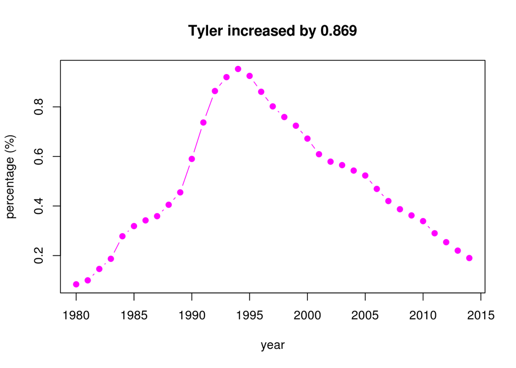

#### The name has had the largest precentage decrease：

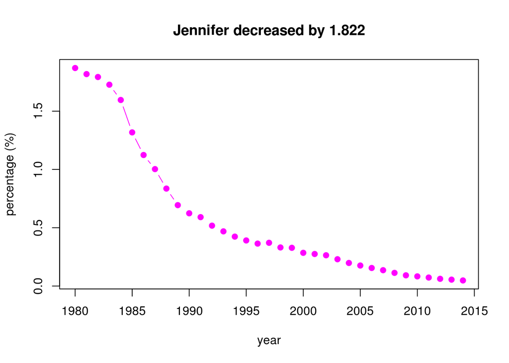

### Can you identify names that may have had an even larger increase or decrease in popularity?

#### The name has had the most popularity increase :

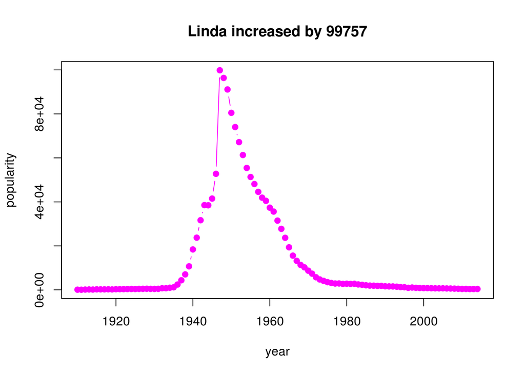

#### The name has had the most popularity decreased :

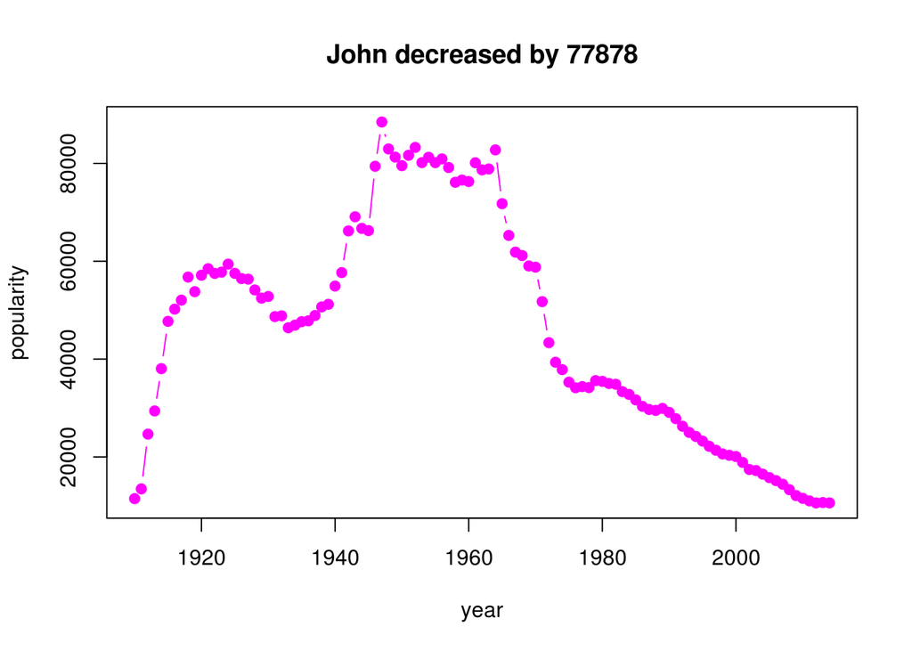

# B) Insights!

### The most popular names for each year

#### The most pouplar female names:

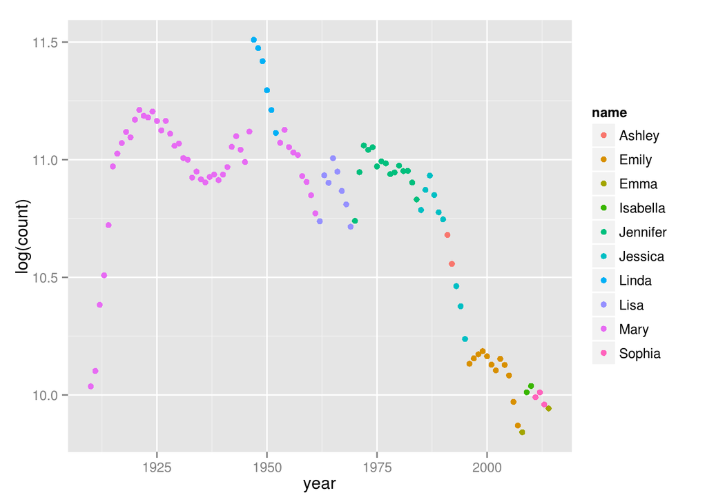

#### The most popular male names

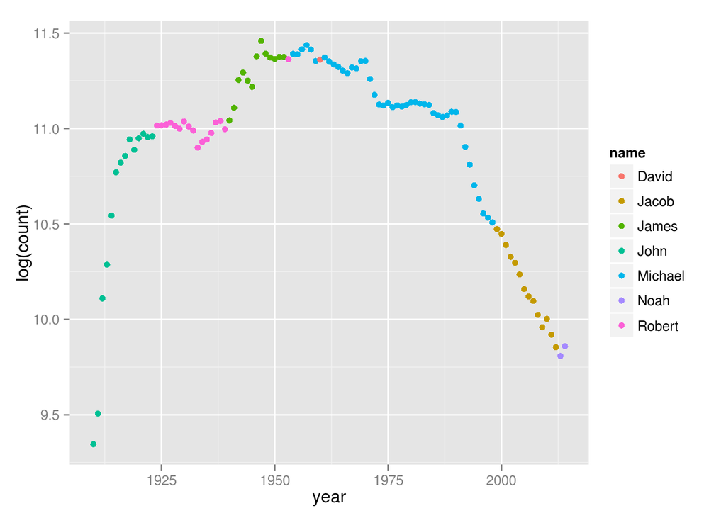

#### Plot of the number of distinct female names each year

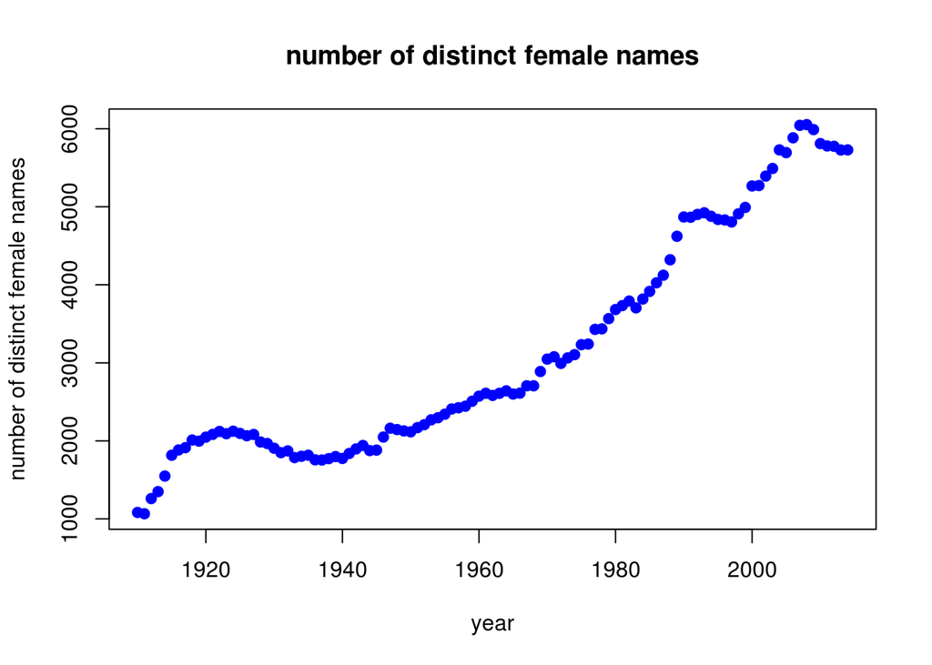

#### Plot of the number of distinct male names each year

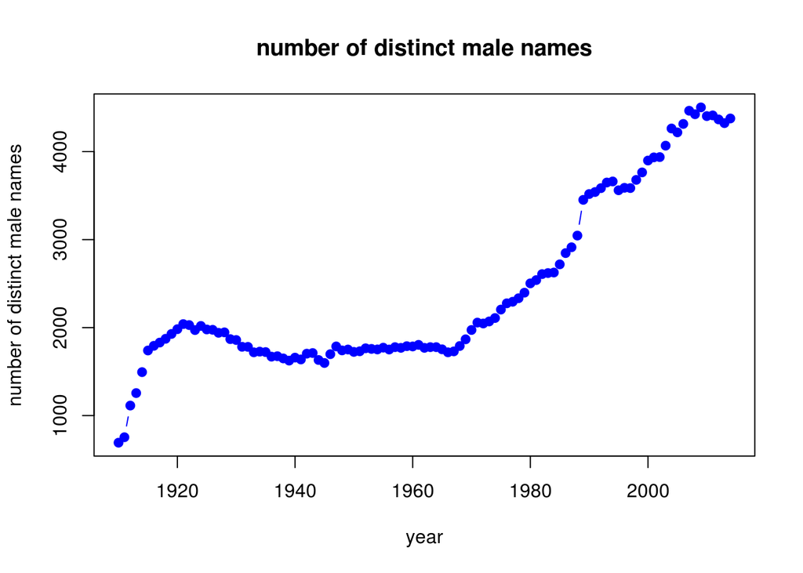

### The ambiguous names

#### The female names change to the male names over the time:

```
##  [1] "Robbie"    "Toby"      "Jean"      "Donnie"    "Dana"
##  [6] "Frankie"   "Joan"      "Ivy"       "Trinidad"  "Terry"
## [11] "Augustine"
```

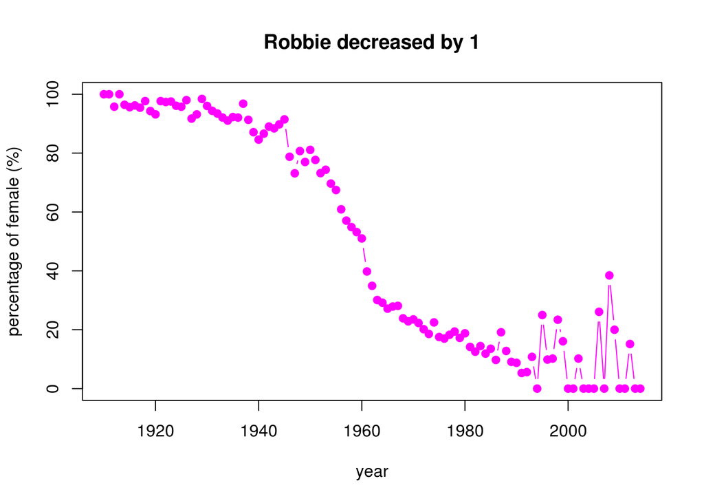

#### The male names change to the female names over the time:

```
##  [1] "Lacy"    "Lindsey" "Kelly"   "Aubrey"  "Morgan"  "Sandy"   "Leslie"
##  [8] "Shelby"  "Blair"   "Sydney"  "Lynn"    "Charley" "Ivory"   "Loren"
## [15] "Rosario" "Sidney"  "Emery"
```

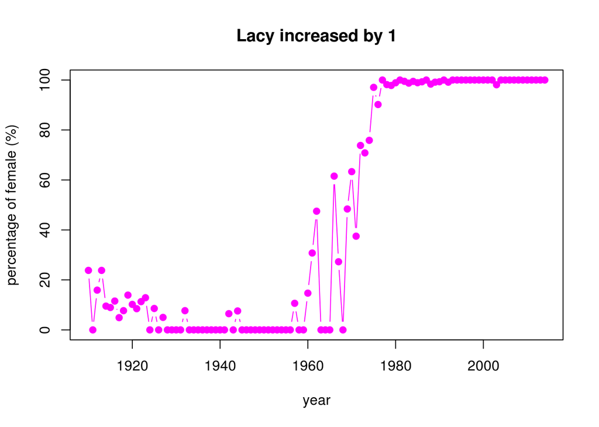

### Scale plots and video

- For a given name, we can identify the popularity distrubtion over the states in a certain year. For example, the following plot shows the popularity distribution for “Mary” in 1980. The video file **‘out.avi’** shows the state popularity distribution for “Mary” from 1910 to 2014

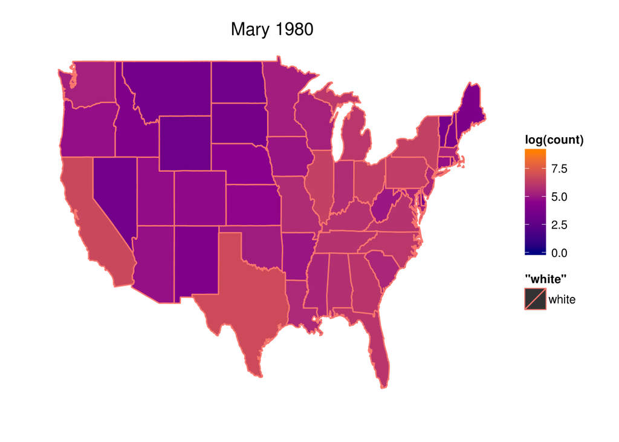

### heatmap plots

- For a given name, the popularity distributions over the time and states can be shown in the heatmap. For example, the following plot shows the heatmap for “Mary”.

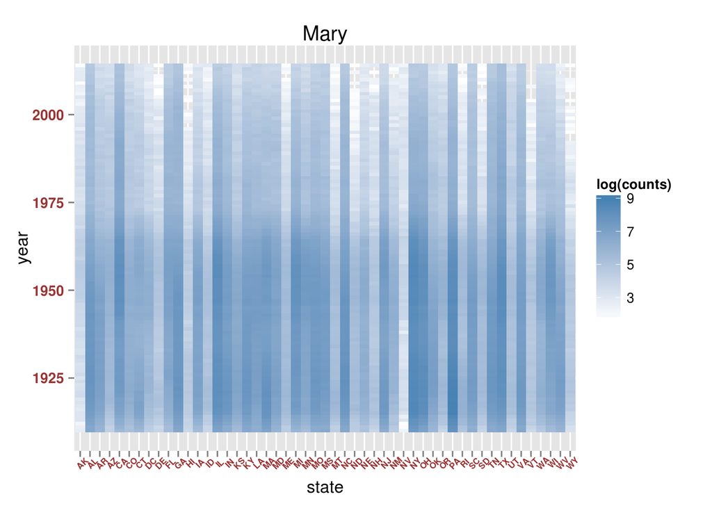